# **Analysis of Global Musical Artist Listeners and Genres**

### Data

**Source**  
The original dataset was downloaded from Kaggle and contains data from MusicBrainz and LastFM. https://www.kaggle.com/datasets/pieca111/music-artists-popularity  
**Cleaning**  
Due to the size and crowdsourced nature of the dataset, some cleaning was necessary to make it manageable for our analysis. Steps taken include:

- Deleted artists with less than 100,000 listeners, shrinking the file size from 1.04 million lines to under 8000 lines.
- Reduced the number of columns artist, country, tags (genres), listeners
- Removed any duplicate columns, using all data from LastFM. Any MusicBrainz columns were removed.
- Modified the country column to contain only the first value in instances where more than one country was listed. Countries are listed alphabetically, therefore we acknowledge that this weights countries toward front of alphabet. For example, if an artist is listed as being from both Armenia and the United States, Armenia would be the country left in the cleaned dataset.
- Reduced tags to the first five in separate columns: tags1_lastfm, tags2_lastfm, tags3_lastfm, tags4_lastfm, tags5_lastfm. Tags are user-generated, are not a controlled vocabulary, and appeared to be random in order. As such, tags are inconsistently applied, sometimes repetitive, and not necessarily accurate. They are, however, the closest approximation to music genre in this dataset.

### Questions

**Main Question:**  
Given the fields in the principle dataset: artist, country of origin (by artist), number of monthly listeners on LastFM, and user-generated tags, what comparisons can we make across those fields?  
**Sub Questions:**  
How many listeners does each top artist have?  
How many listeners does each top country have?  
What genres have the most listeners?  
How many artists are associated with each genre?  
What are the top most common genres by country?  
Compare ambiguous artists (true/false), sum listeners.

### Analysis

#### Import necessary packages

```python
# IMPORTS
import numpy as np
import pandas as pd
import os
import matplotlib.pyplot as plt
import openpyxl
import seaborn as sns
import ipywidgets as widgets
from ipywidgets import widgets, interactive, Layout
```

#### Top Artists By Listeners

We use a scatter plot to visualize the total number of listerners per artist (using artist index).

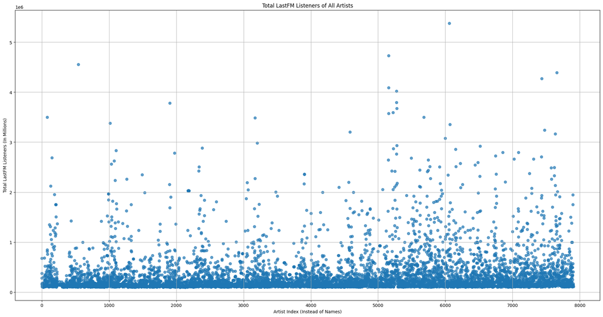

```python
data = pd.read_csv('Mapd.csv', low_memory=False) #import data

data['artist_lastfm'] = data['artist_lastfm'].astype(str) #make the artist names consistent

data = data.dropna(subset=['artist_lastfm', 'listeners_lastfm']) #remove n/a

data['artist_lastfm'] = data['artist_lastfm'].str.replace('$', 'S', regex=False) #change dollar signs in artist names to actual "s"

plt.figure(figsize=(24, 12))
plt.scatter(data.index, data['listeners_lastfm'], alpha=0.7) #creating a scatter plot with the artist index position on the x-axis and amount of listeners on the y-position.
plt.xlabel('Artist Index (Instead of Names)')
plt.ylabel('Total LastFM Listeners (In Millions)')
plt.title('Total LastFM Listeners of All Artists') #adding labels and titles
plt.grid(True) #adding grid lines for readability
```

The scatter plot was not helpful in analyzing the data, so we first displayed it as a tabular sorted list.

```python
sort_top25_data = data.sort_values(by = "listeners_lastfm", ascending = False) #sorting the data into a list from largest amount of listeners to least amount.
sort_top25_data.head(25) #showing the first 25 artists, by listeners, from the list
```

|  | mbid | artist_lastfm | country_lastfm | tags1_lastfm | tags2_lastfm | tags3_lastfm | tags4_lastfm | tags5_lastfm | tags_lastfm | listeners_lastfm | ambiguous_artist |
| --- | --- | --- | --- | --- | --- | --- | --- | --- | --- | --- | --- |
| 6060 | cc197bad-dc9c-440d-a5b5-d52ba2e14234 | David Lee Roth | United Kingdom | rock | alternative | britpop | alternative rock | indie | rock alternative britpop alternative rock indie | 5381567.0 | False |
| 5156 | a74b1b7f-71a5-4011-9441-d0b5e4122711 | Robert Rich | United Kingdom | alternative | alternative rock | rock | indie | electronic | alternative alternative rock rock indie electr... | 4732528.0 | False |
| 544 | 73e5e69d-3554-40d8-8516-00cb38737a1c | Elis Regina | Barbados | pop | rnb | female vocalists | dance | Hip-Hop | pop rnb female vocalists dance Hip-Hop | 4558193.0 | False |
| 7659 | 164f0d73-1234-4e2c-8743-d77bf2191051 | Michael Franks | United States | Hip-Hop | rap | hip hop | rnb | Kanye West | Hip-Hop rap hip hop rnb Kanye West | 4390502.0 | False |
| 7433 | 5b11f4ce-a62d-471e-81fc-a69a8278c7da | EVE 6 | United States | Grunge | rock | alternative | alternative rock | 90s | Grunge rock alternative alternative rock 90s | 4272894.0 | False |
| 5155 | 9c9f1380-2516-4fc9-a3e6-f9f61941d090 | Balligomingo | United Kingdom | alternative rock | rock | alternative | Progressive rock | seen live | alternative rock rock alternative Progressive ... | 4089612.0 | False |
| 5272 | 0383dadf-2a4e-4d10-a46a-e9e041da8eb3 | Bobby """"Blue"""" Bland | United Kingdom | classic rock | rock | 80s | hard rock | glam rock | classic rock rock 80s hard rock glam rock | 4023379.0 | False |
| 5274 | b071f9fa-14b0-4217-8e97-eb41da73f598 | Samuel L. Jackson | United Kingdom | classic rock | rock | british | 60s | blues | classic rock rock british 60s blues | 3798330.0 | False |
| 1903 | 056e4f3e-d505-4dad-8ec1-d04f521cbb56 | Dominik Eulberg | France | electronic | dance | House | electronica | techno | electronic dance House electronica techno | 3782404.0 | False |
| 5276 | b10bbbfc-cf9e-42e0-be17-e2c3e1d2600d | Slim Harpo | United Kingdom | classic rock | rock | british | 60s | pop | classic rock rock british 60s pop | 3674017.0 | False |
| 5224 | 39ab1aed-75e0-4140-bd47-540276886b60 | Elmore James | United Kingdom | britpop | rock | british | alternative | indie | britpop rock british alternative indie | 3592076.0 | False |
| 5157 | e21857d5-3256-4547-afb3-4b6ded592596 | Benoît Pioulard | United Kingdom | alternative | electronic | Hip-Hop | rock | indie | alternative electronic Hip-Hop rock indie | 3577998.0 | False |
| 5682 | ada7a83c-e3e1-40f1-93f9-3e73dbc9298a | Out Hud | United Kingdom | indie rock | indie | british | rock | alternative | indie rock indie british rock alternative | 3501680.0 | False |
| 81 | cc0b7089-c08d-4c10-b6b0-873582c17fd6 | Chet Faker | Armenia | metal | alternative metal | rock | Nu Metal | alternative | metal alternative metal rock Nu Metal alternative | 3497648.0 | False |
| 3170 | a3cb23fc-acd3-4ce0-8f36-1e5aa6a18432 | C-Bool | Ireland | rock | classic rock | irish | pop | alternative | rock classic rock irish pop alternative | 3487345.0 | False |
| 1017 | 9fff2f8a-21e6-47de-a2b8-7f449929d43f | Rick Astley | Canada | Hip-Hop | rap | rnb | hip hop | Canadian | Hip-Hop rap rnb hip hop Canadian | 3379644.0 | False |
| 6068 | 5441c29d-3602-4898-b1a1-b77fa23b8e50 | Sammy Hagar | United Kingdom | rock | glam rock | classic rock | 80s | alternative | rock glam rock classic rock 80s alternative | 3354711.0 | False |
| 7473 | eeb1195b-f213-4ce1-b28c-8565211f8e43 | OneRepublic | United States | hard rock | rock | classic rock | 80s | metal | hard rock rock classic rock 80s metal | 3241492.0 | False |
| 4584 | aa7a2827-f74b-473c-bd79-03d065835cf7 | Steps | Scotland | indie | indie rock | rock | alternative | seen live | indie indie rock rock alternative seen live | 3203026.0 | False |
| 7635 | f82bcf78-5b69-4622-a5ef-73800768d9ac | Common Rider | United States | Hip-Hop | rap | hip hop | east coast rap | jay-z | Hip-Hop rap hip hop east coast rap jay-z | 3169635.0 | False |
| 5997 | 83d91898-7763-47d7-b03b-b92132375c47 | New York Dolls | United Kingdom | Progressive rock | classic rock | Psychedelic Rock | rock | psychedelic | Progressive rock classic rock Psychedelic Rock... | 3081313.0 | False |
| 3201 | a66999a7-ae5c-460e-ba94-1a01143ae847 | Rui Da Silva | Ireland | indie | alternative | rock | indie rock | britpop | indie alternative rock indie rock britpop | 2982390.0 | False |
| 5279 | 678d88b2-87b0-403b-b63d-5da7465aecc3 | Jonathan Groff | United Kingdom | classic rock | rock | hard rock | 70s | Progressive rock | classic rock rock hard rock 70s Progressive rock | 2930957.0 | False |
| 6515 | 309c62ba-7a22-4277-9f67-4a162526d18a | Margot & the Nuclear So and So's | United States | alternative | indie | rock | singer-songwriter | indie rock | alternative indie rock singer-songwriter indie... | 2918241.0 | False |
| 2385 | ea4dfa26-f633-4da6-a52a-f49ea4897b58 | The Bloody Beetroots | Georgia | rock | alternative rock | alternative | indie | seen live | rock alternative rock alternative indie seen live | 2886482.0 | False |

Then we visualized the data using a horizontal bar chart. Instead of artist index, we used the name of the artist.

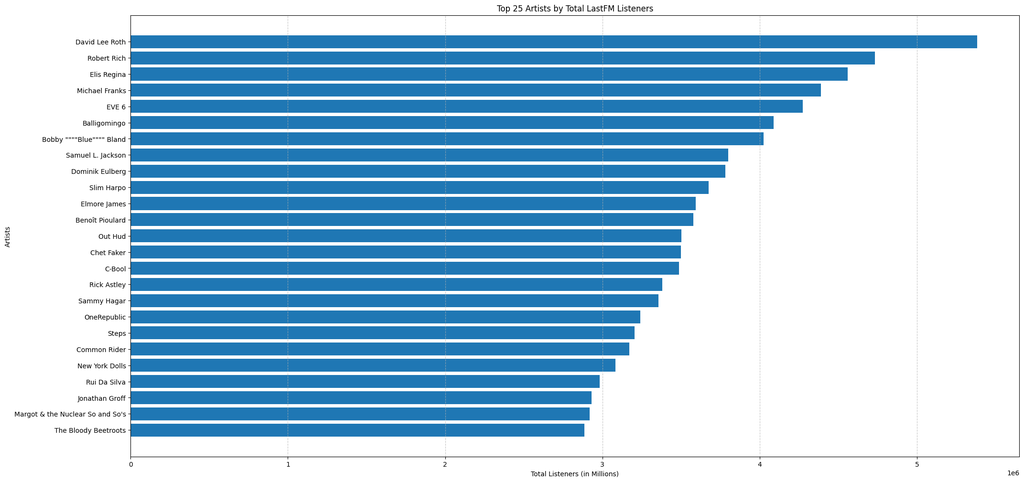

```python
top_25_artists = data.sort_values(by='listeners_lastfm', ascending=False).head(25)

plt.figure(figsize=(24, 12))
plt.barh(top_25_artists['artist_lastfm'], top_25_artists['listeners_lastfm']) #creating a horizontal barchart of the top 25 artists by listeners
plt.xlabel('Total Listeners (in Millions)')
plt.ylabel('Artists')
plt.title('Top 25 Artists by Total LastFM Listeners') #labeling and adding titles
plt.gca().invert_yaxis() #inverting the y-axis so the artist with the highest amount of listeners is up top
plt.grid(axis='x', linestyle='--', alpha=0.7) #adding grid lines

plt.show()
```

The top artist by LastFM listeners, David Lee Roth, had over 5 million LastFM listeners and had 600,000 and 800,000 more listeners than the 2nd and 3rd top artists, respectively. The top seven aritsts all had over 4 million listeners.

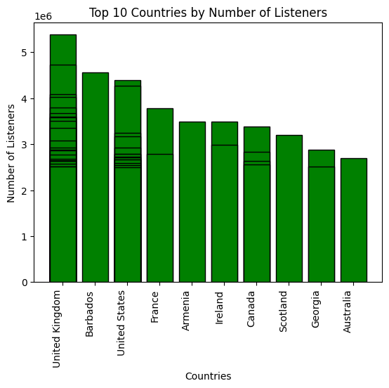

```python
# 'low_memory=False' for better handling of large files
data = pd.read_csv('Mapd.csv', low_memory=False)
# Convert the 'country_lastfm' column to string
data['country_lastfm'] = data['country_lastfm'].astype(str)
# removes any rows or columns with no data
data = data.dropna(subset=['country_lastfm', 'listeners_lastfm'])
#sorts the data descending and selects top 50
top10 = data.sort_values(by='listeners_lastfm', ascending=False).head(50)
# tells the code which columns to look at
countries = top10['country_lastfm']
listeners = top10['listeners_lastfm']
# creates a bar chart
plt.bar(countries, listeners, color='green', edgecolor='black')
# adds detail to the bar chart
plt.title('Top 10 Countries by Number of Listeners')
plt.xlabel('Countries')
plt.ylabel('Number of Listeners')
# adjusts the xaxis label
plt.xticks(rotation=90, ha='right')
#displays the bar chart
plt.show()
```

#### Top Tags By Total Listeners

We display the top genres by total listeners using a violin plot.

```python
# Show the count of each tag/genre that appears throughout the dataset
df = pd.DataFrame(data)

counts = df['tags1_lastfm'].value_counts()
print(counts)
```

```
tags1_lastfm
electronic          485
Hip-Hop             467
indie               381
pop                 294
rock                241
                   ...
glitch-hop            1
Christian Rap         1
Elephant 6            1
a capella             1
a cappella metal      1
Name: count, Length: 348, dtype: int64
```

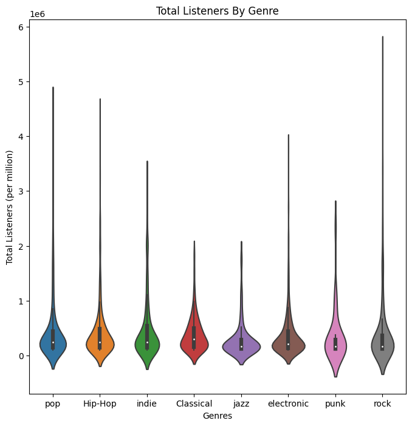

```python
df = pd.DataFrame(data)

# Create a new Data Frame only including the most popular Genres in the dataset.

genres = ['rock', 'pop', 'Hip-Hop', 'jazz', 'electronic', 'Classical', 'indie', 'punk']
df_filter = df[df['tags1_lastfm'].isin(genres)]

# Once the counts of the most popular genres are identified, we can create our visualization

plt.figure(figsize=(8,8))
sns.violinplot(data=df_filter, x='tags1_lastfm', y='listeners_lastfm')

# Provide proper Labels and Titles

plt.xlabel('Genres')
plt.ylabel('Total Listeners (per million)')
plt.title('Total Listeners By Genre')

plt.show()
```

#### Number of Artists by Genre

Using a horizontal bar graph, we visual the number of artists associated with top tags.

```python
#Load the .csv dataset into a dataframe
df = pd.read_csv('Mapd.csv', low_memory=False)

# Track count of artist genres
artist_counts = {}

for index, row in df.iterrows():
    # Get the genres from the 5 tag columns and get rid of duplicates and blanks
    genres = [row['tags1_lastfm'], row['tags2_lastfm'], row['tags3_lastfm'], row['tags4_lastfm'], row['tags5_lastfm']]
    genres = [genre for genre in genres if pd.notna(genre) and genre.strip() != '']
    genres = list(set(genres))

    # Count the genres
    for genre in genres:
        if genre in artist_counts:
            artist_counts[genre] += 1
        else:
            artist_counts[genre] = 1

artist_counts_df = pd.DataFrame(list(artist_counts.items()), columns=['Genre', 'Artist Count'])
artist_counts_sorted = artist_counts_df.sort_values('Artist Count', ascending=False).reset_index(drop=True)

print(artist_counts_sorted)
```

```
                  Genre  Artist Count
0            electronic          1528
1             seen live          1401
2                  rock          1368
3                 indie          1065
4      female vocalists          1002
...                 ...           ...
2116   experimental rap             1
2117      Justus League             1
2118    FUCKING AWESOME             1
2119        electro-pop             1
2120         9th wonder             1

[2121 rows x 2 columns]
```

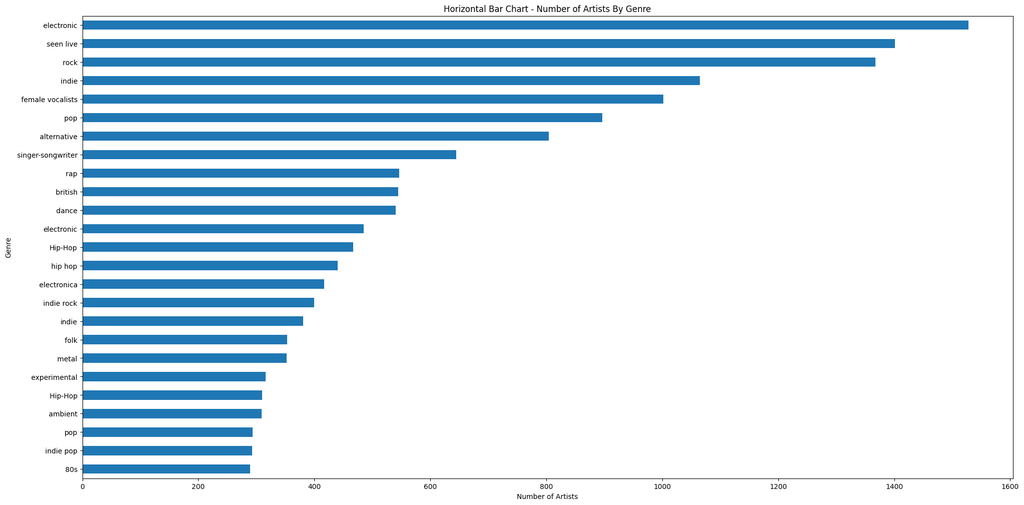

```python
#Get the sorted list of most popular genres
df_sorted = artist_counts_sorted.sort_values(by='Artist Count', ascending=False).head(25)
df_sorted.plot.barh(x='Genre', y='Artist Count', legend=False, figsize=(24,12))

#Plot the barh
plt.gca().invert_yaxis()
plt.xlabel('Number of Artists')
plt.ylabel('Genre')
plt.title('Horizontal Bar Chart - Number of Artists By Genre')

plt.show()
```

#### Top 5 Genres Per Country (Interactive Choice)

We use an dropdown selector to choose a country and then visualize the top five musical tags in that country using a bar chart.

```python
df = pd.read_csv("Mapd.csv", low_memory=False)

# User-defined function to get the most popular tags for a specific country
def get_popular_tags_by_country(country_lastfm):
    country_data = df[df['country_lastfm'] == country_lastfm]

    tags_columns = ['tags1_lastfm', 'tags2_lastfm', 'tags3_lastfm', 'tags4_lastfm', 'tags5_lastfm']
    all_tags = country_data[tags_columns].values.flatten() # Flatten tags into list

    all_tags = [tag for tag in all_tags if pd.notna(tag)] # Remove NaN

    tag_counts = pd.Series(all_tags).value_counts()

    return tag_counts.head(5) # Return top 5 tags

# User-defined function to be executed when a country is selected
def on_country_selected(country_lastfm):
    popular_tags = get_popular_tags_by_country(country_lastfm)

    result_text = f"Most Popular Tags for {country_lastfm}:\n"
    for tag, count in popular_tags.items():
        result_text += f"{tag}: {count}\n"

    result_label.value = result_text

    # Create bar plot for Top 5 Tags for selected country
    fig, ax = plt.subplots(figsize=(8, 6))
    popular_tags.plot(kind='bar', ax=ax, color='blue')
    ax.set_title(f"Top 5 Tags for {country_lastfm}")
    ax.set_xlabel("Tags")
    ax.set_ylabel("Frequency")
    plt.xticks(rotation=45, ha="right")

plt.show()

# Create interactive dropdown widget to select country
country_dropdown = widgets.Dropdown(
    options=df['country_lastfm'].unique().tolist(),
    description='Country:',
    disabled=False
)

result_label = widgets.Label(value="Select a country to see the most popular tags.")

interactive_widget = interactive(on_country_selected, country_lastfm=country_dropdown)

display(interactive_widget, result_label)
```

```
interactive(children=(Dropdown(description='Country:', options=('Afghanistan', 'Albania', 'Algeria', 'Andorra'…
```

```
Label(value='Most Popular Tags for Afghanistan:\nqawwali: 1\n world: 1\n sufi: 1\n pakistani: 1\n World Music:…
```

#### Ambiguous Artists vs. Number of Monthly Listeners

Using a box plot we can visualize the difference in listeners when comparing if an artist has an ambiguous name or not.

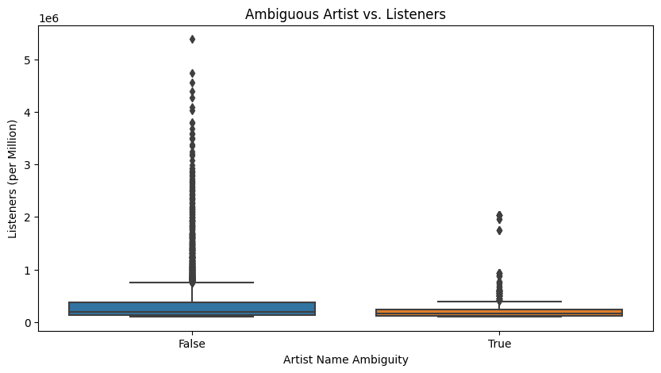

```python
#Set size and type of visualization, including what data will be used.
plt.figure(figsize=(10,5))
sns.boxplot(data=df, x='ambiguous_artist', y='listeners_lastfm')

#Provide a title and proper labels
plt.xlabel('Artist Name Ambiguity')
plt.ylabel('Listeners (per Million)')
plt.title('Ambiguous Artist vs. Listeners')

#Show visualization
plt.show()
```

### Machine Learning Attempts

#### Unsupervised Learning

```python
df = pd.read_csv('Mapd.csv', low_memory=False)
df = df[["listeners_lastfm", "ambiguous_artist"]]
df = df.dropna() #of the two coloumns, drop any N/A's
df
```

|  | listeners_lastfm | ambiguous_artist |
| --- | --- | --- |
| 0 | 163604.0 | False |
| 1 | 678284.0 | False |
| 2 | 279962.0 | False |
| 3 | 375102.0 | False |
| 4 | 127056.0 | False |
| ... | ... | ... |
| 7899 | 145081.0 | False |
| 7900 | 145081.0 | False |
| 7901 | 406492.0 | False |
| 7902 | 165955.0 | False |
| 7903 | 110502.0 | False |

7904 rows × 2 columns

```python
features = ["listeners_lastfm", "ambiguous_artist"]
X = df[features] #defining the features

X['ambiguous_artist'] = X['ambiguous_artist'].apply(lambda x: 1 if x == "True" else 0) #if the ambiguous artist is True, change it to a 1, if not, make it a zero
X
```

|  | listeners_lastfm | ambiguous_artist |
| --- | --- | --- |
| 0 | 163604.0 | 0 |
| 1 | 678284.0 | 0 |
| 2 | 279962.0 | 0 |
| 3 | 375102.0 | 0 |
| 4 | 127056.0 | 0 |
| ... | ... | ... |
| 7899 | 145081.0 | 0 |
| 7900 | 145081.0 | 0 |
| 7901 | 406492.0 | 0 |
| 7902 | 165955.0 | 0 |
| 7903 | 110502.0 | 0 |

7904 rows × 2 columns

```python
from sklearn.cluster import KMeans

kmeans = KMeans(n_clusters=3, random_state=0) #set the number of clusters to 3 and random state to zero, so we can all get the same results
kmeans
```

```
KMeans(n_clusters=3, random_state=0)
```

```python
kmeans.fit(X) #checking the fit of the model to the training data
```

```
KMeans(n_clusters=3, random_state=0)
```

```python
kmeans.predict(X) #having the model assign the data to 3 clusters
```

```
array([0, 1, 0, ..., 0, 0, 0], dtype=int32)
```

```python
df["label"] = kmeans.predict(X) #show the assigned clusters in the df rows
df
```

|  | listeners_lastfm | ambiguous_artist | label |
| --- | --- | --- | --- |
| 0 | 163604.0 | False | 0 |
| 1 | 678284.0 | False | 1 |
| 2 | 279962.0 | False | 0 |
| 3 | 375102.0 | False | 0 |
| 4 | 127056.0 | False | 0 |
| ... | ... | ... | ... |
| 7899 | 145081.0 | False | 0 |
| 7900 | 145081.0 | False | 0 |
| 7901 | 406492.0 | False | 0 |
| 7902 | 165955.0 | False | 0 |
| 7903 | 110502.0 | False | 0 |

7904 rows × 3 columns

```python
df.label.value_counts() #sum the results of the clusters
```

```
label
0    6724
1     970
2     210
Name: count, dtype: int64
```

```python
cluster_1st, cluster_2nd, cluster_3rd = df.label.value_counts().index #naming all the clusters
cluster_1st, cluster_2nd, cluster_3rd
```

```
(0, 1, 2)
```

```python
df[df.label == cluster_1st].sample(n=10, random_state=0) #calling up 10 random samples from the df of the first cluster.
```

|  | listeners_lastfm | ambiguous_artist | label |
| --- | --- | --- | --- |
| 2849 | 238945.0 | True | 0 |
| 7795 | 141287.0 | False | 0 |
| 1832 | 108959.0 | True | 0 |
| 5238 | 389066.0 | True | 0 |
| 5624 | 100313.0 | False | 0 |
| 6536 | 111413.0 | True | 0 |
| 3412 | 136426.0 | True | 0 |
| 5323 | 378582.0 | False | 0 |
| 3648 | 253068.0 | True | 0 |
| 7258 | 199069.0 | False | 0 |

```python
df[df.label == cluster_2nd].sample(n=10, random_state=0) #calling up 10 random samples from the df of the second cluster.
```

|  | listeners_lastfm | ambiguous_artist | label |
| --- | --- | --- | --- |
| 7695 | 1470451.0 | False | 1 |
| 3252 | 825250.0 | False | 1 |
| 136 | 550489.0 | False | 1 |
| 6160 | 952286.0 | False | 1 |
| 5152 | 561265.0 | False | 1 |
| 6656 | 625526.0 | False | 1 |
| 6174 | 844887.0 | False | 1 |
| 7134 | 676501.0 | False | 1 |
| 4565 | 593270.0 | False | 1 |
| 5589 | 829178.0 | False | 1 |

```python
df[df.label == cluster_3rd].sample(n=10, random_state=0) #calling up 10 random samples from the df of the third cluster.
```

|  | listeners_lastfm | ambiguous_artist | label |
| --- | --- | --- | --- |
| 992 | 1966716.0 | True | 2 |
| 4584 | 3203026.0 | False | 2 |
| 2175 | 2030349.0 | True | 2 |
| 209 | 1754155.0 | True | 2 |
| 7429 | 2709816.0 | False | 2 |
| 4645 | 1609221.0 | False | 2 |
| 5532 | 1924069.0 | False | 2 |
| 5623 | 1540288.0 | False | 2 |
| 4883 | 1671502.0 | False | 2 |
| 6223 | 2577949.0 | False | 2 |

**Unsupervised Learning Conclusion:** The model determined that, of the three clusters formed, first cluster (0) had a mix of ambiguous artists and lower listener numbers, the second cluster had no ambiguous artists and high amounts of listeners, and the third cluster had a low mix of ambiguous artists but high listener counts.

#### Supervised Learning

```python
df = df.iloc[range(7904)]
df
```

|  | listeners_lastfm | ambiguous_artist | label |
| --- | --- | --- | --- |
| 0 | 163604.0 | False | 0 |
| 1 | 678284.0 | False | 1 |
| 2 | 279962.0 | False | 0 |
| 3 | 375102.0 | False | 0 |
| 4 | 127056.0 | False | 0 |
| ... | ... | ... | ... |
| 7899 | 145081.0 | False | 0 |
| 7900 | 145081.0 | False | 0 |
| 7901 | 406492.0 | False | 0 |
| 7902 | 165955.0 | False | 0 |
| 7903 | 110502.0 | False | 0 |

7904 rows × 3 columns

```python
#For our first test we are going to run a linear regression.
from sklearn.linear_model import LogisticRegression
lr = LogisticRegression()
lr
```

```
LogisticRegression()
```

```python
from sklearn.model_selection import train_test_split
from sklearn.preprocessing import StandardScaler

#Convert True and False to binary code. After running into errors with the .apply function, we decided to use the .astype function.
df['ambiguous_artist'] = df['ambiguous_artist'].astype(int)

#Set the features and targets to listeners and artist ambiguity to run our predictive models
features = ['listeners_lastfm']
target = ['ambiguous_artist']
X = df[features]
y = df[target]

#will discuss this further in the presentation
scaler = StandardScaler()
X_scaled = scaler.fit_transform(X)
```

```python
#Set test size, random state and then ultimately fit our regressions.
X_train, X_test, y_train, y_test = train_test_split(X, y, test_size=0.25, random_state=0)

lr = LogisticRegression()
lr.fit(X_train, y_train)
```

```
LogisticRegression()
```

```python
#Run the linear regression scores against the training data and test data
lr.score(X_train, y_train), lr.score(X_test, y_test)
```

```
(0.771255060728745, 0.7677125506072875)
```

```python
#Create a dictionary containing the test scores of different models
summary = dict()

summary["LR"] = round(lr.score(X_test, y_test), 3)
summary
```

```
{'LR': 0.768}
```

```python
#Run the closest neighbors test.
from sklearn.neighbors import KNeighborsClassifier
#Fit the model
knc = KNeighborsClassifier(n_neighbors=2)
knc.fit(X_train, y_train)
#Run the scores against the data.
knc.score(X_train, y_train), knc.score(X_test, y_test)
```

```
(0.9875168690958165, 0.9089068825910931)
```

```python
#Apply new scores to the dictionary
summary["K-NNs"] = round(knc.score(X_test, y_test), 3)
summary
```

```
{'LR': 0.768, 'K-NNs': 0.909}
```

```python
#Fit and run the Random Forest Classifier model
from sklearn.ensemble import RandomForestClassifier

rfc = RandomForestClassifier(random_state=10)
rfc.fit(X_train, y_train)
```

```
RandomForestClassifier(random_state=10)
```

```python
#Add next score to the current dictionary
rfc.score(X_train, y_train), rfc.score(X_test, y_test)
summary["RF"] = round(rfc.score(X_test, y_test), 3)
```

```python
#Fit and run the Linear SVC model
from sklearn.svm import LinearSVC

lsvc = LinearSVC(random_state=0)
lsvc.fit(X_train, y_train)
```

```
LinearSVC(random_state=0)
```

```python
#Add next score to the current dictionary
lsvc.score(X_train, y_train), lsvc.score(X_test, y_test)
summary["Linear SVCs"] = round(lsvc.score(X_test, y_test), 3)
```

```python
#View all scores to determine which model will work the best. In this case, we went with the Random Forest Classifier Model
summary
```

```
{'LR': 0.768, 'K-NNs': 0.909, 'RF': 0.939, 'Linear SVCs': 0.768}
```

```python
#Create some random artists with varying listener counts
artist1 = {"listeners_lastfm": 190000,    # Artist with varying listeners
           }
artist2 = {"listeners_lastfm": 1400000,
           }

#Add an empty list
X_new = []

#Extract correct values to add to the empty list
for artist in [artist1, artist2]:
    new_artist = [artist["listeners_lastfm"]]
    X_new.append(new_artist)

#Create a data frame with the correct format
X_new = pd.DataFrame(data=X_new, columns=["listeners_lastfm"])
X_new = X_new[features]

#After realizing that there was an issue with the dataframe shape, I used the scaler function to properly format the dataframe. This was also done in cell 17 above.
X_new_scaled = scaler.transform(X_new)
```

```python
#Use the model to predict whether or not each artist will have a unique or ambiguous name or not
predict_rfc = rfc.predict(X_new)
predict_knn = knc.predict(X_new)
```

```python
# The model predicts that both random artists will have non-ambiguous names
predict_rfc
```

```
array([0, 0])
```

```python
#Using the next highest scored model, we get the same result
predict_knn
```

```
array([0, 0])
```

#### Conclusion

Our analysis aimed to explore the relationships between artist, country of origin, number of monthly listeners on LastFM, and user-generated tags to identify meaningful comparisons across these fields. We uncovered key insights into how these attributes interact through data cleaning, visualization, and statistical exploration.

Key Comparisons: Country vs. Popularity: Certain countries produce a higher concentration of globally recognized artists, while others have strong regional followings. The distribution of monthly listeners varies significantly across countries, highlighting the global reach of some artists compared to those with more localized appeal.

Genre (Tags) vs. Popularity: User-generated tags provided a diverse look at how artists are categorized. Some genres exhibit widespread popularity across multiple countries, while niche genres show strong regional or cultural significance.

Country vs. Genre Representation: Specific genres are more dominant in certain countries, reflecting cultural and industry trends. For example, some nations have a strong presence in electronic music, while others are well-known for rock or hip-hop.

By comparing these fields, we better understood how artist popularity, country of origin, and genre are interwoven in global music trends. Future exploration could integrate additional data sources, such as streaming platform engagement, social media activity, or tour locations, to refine these comparisons further and provide a more comprehensive view of artist influence.